# Basic Digital Out Functionality

Andrey Samokhin

2026-09-22

## Experimental setup

The examples in this vignette were recorded using an Analog Discovery 2 NI Edition and a Rigol DHO804 digital oscilloscope.

The examples and descriptions were checked against WaveForms SDK 3.25 and the WaveForms SDK Reference Manual revised March 4, 2026.

### Pattern generator

The examples were tested using a Digilent Analog Discovery 2 NI Edition.

The device is opened with `OpenDevice()`, used throughout the vignette, and closed after the final example. Its information is shown below; the serial number has been masked because it is not relevant to reproducing the examples.

When exactly one device is available, `OpenDevice()` selects it automatically; if several devices are connected, specify the required device by serial number.

```r
device <- OpenDevice()

print(device$info)
```

```
#> $device_type
#> [1] "Analog Discovery 2"
#>
#> $device_revision
#> [1] 2051
#>
#> $device_name
#> [1] "Analog Discovery 2 NI EditionSN:Discovery2NI"
#>
#> $user_name
#> [1] "Discovery2NI"
#>
#> $serial_number
#> [1] "SN:************"
#>
#> $config_count
#> [1] 8
```

### Oscilloscope

The waveforms shown in this vignette were measured using a Rigol DHO804 oscilloscope. Up to four Digital Out channels were connected to four oscilloscope inputs, and the Analog Discovery ground terminal was connected to the corresponding oscilloscope grounds.

For each example, the waveform was generated using the displayed R code, the oscilloscope settings were adjusted to show the relevant signal properties, and a screenshot was saved for inclusion in the vignette. The R code is not evaluated during vignette rendering because it requires connected hardware.

## Generate a pulse waveform

Among the available Digital Out signal-generation functions, `"pulse"` is one of the simplest and most generally useful. It produces a periodic digital signal that alternates between low and high output states.

The signal-generation function is selected with `SetDigitalOutFunction()`. The WaveForms SDK refers to this setting as the Digital Out *type*, whereas `dwf4r` uses the term *function* to maintain consistent naming between Analog Out and Digital Out.

Digital Out also supports several electrical output modes. In `"push_pull"` mode, the output actively drives both the low and high states. In `"open_drain"` mode, the output actively drives the low state and releases the output for the high state, whereas `"open_source"` mode actively drives the high state and releases the output for the low state. The `"three_state"` mode additionally permits a high-impedance output state. The modes supported by a particular channel depend on the device and can be queried with `GetDigitalOutOutputModes()`. Open-drain and open-source operation requires an appropriate external pull resistor; three-state output is available only with supported signal-generation functions. The examples in this vignette use `"push_pull"`, which directly produces the low and high voltage levels required for the demonstrated pulse waveforms.

Unlike Analog Out, Digital Out pulse frequency and duty cycle are not specified directly. Instead, they are determined by three whole-number values: a clock divider and low and high counters. The divider reduces the Digital Out internal clock frequency and determines the duration of one counter step:

$$t_{\mathrm{count}} = \frac{ \mathrm{divider} }{ f_{\mathrm{clock}} }.$$

The low and high counters specify how many counter steps the output remains in the corresponding state. Consequently, the pulse frequency is

$$f_{\mathrm{pulse}} =
\frac{ f_{\mathrm{clock}} }
{ \mathrm{divider} \cdot (N_{\mathrm{low}} + N_{\mathrm{high}}) },$$

and the fraction of each period spent in the high state is

$$D = \frac{ N_{\mathrm{high}} }{ N_{\mathrm{low}} + N_{\mathrm{high}} }.$$

The following example uses these settings to generate a continuous 1 kHz pulse waveform with a 50% duty cycle on the first Digital Out channel.

```r
ResetDigitalOut(device)

EnableDigitalOutChannel(device, channel = 0L)
SetDigitalOutFunction(device, channel = 0L, func = "pulse")
SetDigitalOutOutput(device, channel = 0L, output = "push_pull")

frequency <- 1000
n_counts <- 10L
internal_clock <- GetDigitalOutInternalClockFrequency(device)
divider <- round(internal_clock / (n_counts * frequency))
SetDigitalOutDivider(device, channel = 0L, divider = divider)

SetDigitalOutCounter(
  device,
  channel = 0L,
  low_count = 5L,
  high_count = 5L
)

StartDigitalOut(device)
```

The example begins with `ResetDigitalOut()` to restore the Digital Out instrument to its SDK defaults and provide a reproducible starting point. The first channel is then enabled and configured for push-pull pulse generation. After the timing parameters are set, `StartDigitalOut()` starts the configured Digital Out instrument.

In this example, one pulse period consists of ten counter steps. The calculated divider makes these ten steps correspond to a frequency of 1 kHz. Five steps are assigned to each output state, producing a 50% duty cycle. According to the Analog Discovery 2 specification, its Digital I/O uses 3.3 V CMOS logic. The measured push-pull waveform shows the corresponding low and high logic levels (Figure 1).

[figure not shown]

Figure 1. Oscilloscope trace of the generated 1 kHz pulse waveform with a 50% duty cycle on Digital Out channel 0.

## Modify a running waveform

Digital Out parameters can also be changed while the instrument is running. Because automatic configuration is disabled by `dwf4r`, setting a parameter updates the pending configuration without immediately changing the generated signal. The updated configuration is applied when `StartDigitalOut()` is called, which starts or restarts the Digital Out instrument.

The following code changes the pulse duty cycle from 50% to 20% while retaining the 1 kHz frequency.

```r
SetDigitalOutCounter(
  device,
  channel = 0L,
  low_count = 8L,
  high_count = 2L
)
StartDigitalOut(device)
```

Unlike Analog Out, Digital Out does not provide a separate operation equivalent to `ApplyAnalogOutSettings()`. Calling `StartDigitalOut()` therefore applies the pending configuration by restarting the instrument.

Only the low and high counters are changed; the clock divider and other channel settings retain their previous values. The total number of counter steps remains ten, so the pulse frequency is unchanged. Eight steps are assigned to the low state and two to the high state, producing a 20% duty cycle (Figure 2).

[figure not shown]

Figure 2. Oscilloscope trace after changing the 1 kHz pulse waveform from 50% to 20% duty cycle. The pulse period remains unchanged.

## Inspect and stop waveform generation

The current state of the Digital Out instrument can be retrieved using `GetDigitalOutStatus()`. At this point, the instrument is generating the modified pulse waveform and is therefore in the `"running"` state.

```r
GetDigitalOutStatus(device)
```

```
#> [1] "running"
```

Signal generation can be stopped using `StopDigitalOut()`. Stopping the instrument does not reset its configuration; the configured signals can be started again using `StartDigitalOut()`.

```r
StopDigitalOut(device)
GetDigitalOutStatus(device)
```

```
#> [1] "ready"
```

The `"ready"` state confirms that the Digital Out instrument is no longer generating signals.

## Generate a finite waveform burst

Digital Out generation proceeds through several instrument states (Figure 3). The diagram is a simplified adaptation of the state model presented in the Digilent WaveForms SDK Reference Manual. Digital Out differs from Analog Out in that a single state machine controls all Digital Out channels.

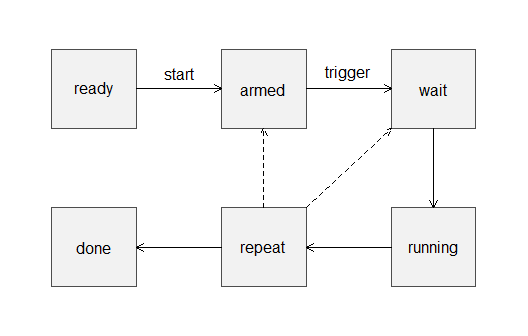

Figure 3. Simplified Digital Out state diagram. Solid arrows show the primary state sequence; dashed arrows show the repeat paths to `"armed"` when repeat triggering is enabled and to `"wait"` when it is disabled.

Before generation starts, the instrument is in the `"ready"` state. Starting Digital Out moves it through `"armed"` and then to `"wait"` under the default configuration used here. The instrument remains in `"wait"` for the configured wait time and then generates all enabled channels during the configured run time. If repetitions remain, the wait-run cycle begins again; otherwise, the instrument enters `"done"`.

By default, the wait time is `0`, the run time is `0`, and the repeat count is `1L`. A run time of `0` requests continuous generation, so the repeat count is not reached. With a finite run time, the repeat count specifies how many wait-run cycles are performed; `0L` requests infinite repetition.

The pulse waveform is generated continuously while the instrument is in the `"running"` state. A finite pulse burst is therefore produced by limiting the Digital Out run time. The following example sets the run time to generate three pulses.

```r
SetDigitalOutRun(device, run_time = 3L / frequency)
StartDigitalOut(device)
```

At 1 kHz, one pulse period is 1 ms, so the configured run time is 3 ms (Figure 4). The repeat count remains at its default value of `1L`, and the run interval is therefore performed once.

[figure not shown]

Figure 4. Oscilloscope trace of a three-pulse, 1 kHz burst generated during a single 3 ms run interval.

The progress of a sufficiently long run interval can be monitored using `GetDigitalOutRemainingRun()`. The following example starts a one-second run, waits for 0.1 seconds, and retrieves the remaining run value.

```r
SetDigitalOutRun(device, run_time = 1)
StartDigitalOut(device)
Sys.sleep(0.1)

remaining_run_value <- GetDigitalOutRemainingRun(device)
remaining_run_value / GetDigitalOutInternalClockFrequency(device)
```

```
#> [1] 0.8450741
```

The WaveForms SDK documentation does not specify the units returned by `FDwfDigitalOutRunStatus()`. On the Analog Discovery 2 used for this vignette, the returned value was consistently found to be expressed in Digital Out internal-clock ticks. Dividing it by the internal clock frequency therefore gives the remaining run time in seconds. This behavior has not been verified for other devices.

The converted value is expected to be slightly below the theoretical value of 0.9 seconds because the elapsed time also includes R execution, device communication, and the status query performed by `GetDigitalOutRemainingRun()`. This function is therefore most useful for monitoring relatively long run intervals rather than precise short-duration timing.

Similarly, `GetDigitalOutRemainingRepeat()` retrieves the number of repeat cycles that have not yet been completed.

```r
SetDigitalOutTiming(
  device,
  run_time = 1 / frequency,
  repeat_count = 1000L
)
StartDigitalOut(device)
Sys.sleep(0.1)

GetDigitalOutRemainingRepeat(device)
```

```
#> [1] 842
```

In the next example, each run interval lasts for one pulse period and is preceded by a wait interval lasting two periods. The wait-run cycle is performed four times.

```r
SetDigitalOutTiming(
  device,
  run_time = 1 / frequency,
  wait_time = 2 / frequency,
  repeat_count = 4L
)
StartDigitalOut(device)
```

With the default configuration restored by `ResetDigitalOut()`, repeated wait-run cycles proceed automatically. The output therefore consists of four single-pulse bursts, each preceded by a 2 ms wait interval (Figure 5).

[figure not shown]

Figure 5. Oscilloscope trace of four repeated pulse bursts. Each 1 ms run interval contains one pulse period and is preceded by a 2 ms wait interval.

## Generate a custom waveform

A custom Digital Out waveform is specified as a vector containing logical low and high samples. Numeric patterns use `0` and `1`; character patterns can use `"l"` and `"h"`. This demonstration uses an eight-sample pattern (Figure 6).

```r
pattern <- c(0, 1, 0, 0, 1, 1, 1, 1)
```

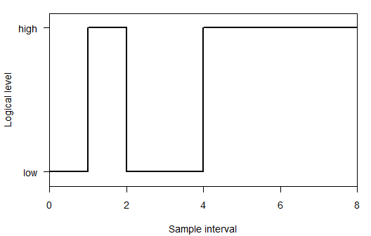

Figure 6. Logical profile of the eight-sample custom Digital Out pattern. Each element represents one interval at the configured sample rate.

To generate a custom waveform, first select the `"custom"` signal-generation function and upload the desired pattern. Then set the `sample_rate`, which specifies how quickly individual pattern elements are generated. It can be viewed as the frequency applied to the individual points of the custom pattern: at a sample rate of 8 kHz, each pattern element lasts 0.125 ms. The sample rate therefore determines the timing of individual pattern elements, not the repetition frequency of the complete pattern.

```r
sample_rate <- 8L * 1000

SetDigitalOutFunction(device, channel = 0L, func = "custom")
SetDigitalOutCustomPattern(
  device,
  channel = 0L,
  pattern = pattern
)
SetDigitalOutCustomSampleRate(
  device,
  channel = 0L,
  sample_rate = sample_rate
)

StartDigitalOut(device)
```

The preceding timing configuration remains active: each 1 ms custom pattern is preceded by a 2 ms wait interval, and the sequence is repeated four times (Figure 7).

[figure not shown]

Figure 7. Oscilloscope trace of four repetitions of the eight-sample custom Digital Out pattern. At a sample rate of 8 kHz, each pattern lasts 1 ms and is preceded by a 2 ms wait interval.

## Control idle output

The idle mode controls a channel output while the Digital Out instrument is not in the `"running"` state, including the `"ready"`, `"wait"`, and `"done"` states. The available idle modes depend on the selected device and channel.

The `"initial"` mode uses the configured initial output value. The `"low"` and `"high"` modes instead force a corresponding logical level while the instrument is idle. The `"three_state"` mode places the output in a high-impedance state and is not demonstrated here.

The following code sets the first channel to the `"high"` idle mode and starts the same four-cycle custom-pattern sequence again (Figure 8).

[figure not shown]

Figure 8. Custom Digital Out pattern generated with the `"high"` idle mode. The output remains at the logical high level during the wait intervals and after generation finishes.

```r
SetDigitalOutIdle(device, channel = 0L, idle = "high")
StartDigitalOut(device)
```

## Inspect capabilities and configured values

Digital Out capabilities depend on the connected device and its selected configuration. Before setting a parameter, `dwf4r` obtains the corresponding capability or supported range from the WaveForms SDK and checks the requested value against it.

The same information can also be queried explicitly. For example, the supported divider range for a selected channel can be retrieved with:

```r
GetDigitalOutDividerRange(device, channel = 0L)
```

```
#> [1] 1 2147483649
```

Currently configured values can be retrieved in a similar way. For example, the divider configured for the same channel can be inspected with:

```r
GetDigitalOutDivider(device, channel = 0L)
```

```
#> [1] 12500
```

The following functions retrieve general Digital Out capabilities:

- `GetDigitalOutChannelCount()`
- `GetDigitalOutInternalClockFrequency()`
- `GetDigitalOutRepeatRange()`
- `GetDigitalOutRunRange()`
- `GetDigitalOutWaitRange()`

The following functions retrieve capabilities of a selected Digital Out channel:

- `GetDigitalOutCounterRange()`
- `GetDigitalOutDividerRange()`
- `GetDigitalOutFunctionTypes()`
- `GetDigitalOutIdleModes()`
- `GetDigitalOutMaxDataBits()`
- `GetDigitalOutOutputModes()`

The current channel configuration can be inspected using:

- `IsDigitalOutChannelEnabled()`
- `GetDigitalOutCounter()`
- `GetDigitalOutCustomSampleRate()`
- `GetDigitalOutDivider()`
- `GetDigitalOutFunction()`
- `GetDigitalOutIdle()`
- `GetDigitalOutInitialCounter()`
- `GetDigitalOutInitialDivider()`
- `GetDigitalOutOutput()`

The instrument-level Digital Out configuration can be inspected using:

- `GetDigitalOutRepeat()`
- `GetDigitalOutRun()`
- `GetDigitalOutTiming()` (it retrieves the run time, wait time, and repeat count together as a named list)
- `GetDigitalOutWait()`

The current Digital Out state and remaining timing values can be inspected using:

- `GetDigitalOutStatus()`
- `GetDigitalOutRemainingRepeat()`
- `GetDigitalOutRemainingRun()`

## Run multiple channels simultaneously

Although Digital Out generation is started and stopped for the instrument as a whole, the waveform can be configured independently for each channel. In particular, the signal-generation function, divider, and counter values are channel-specific, and custom pattern data can also be defined separately for each channel. This makes it possible to generate substantially different signals simultaneously.

The following example configures four channels: a 0.5 kHz pulse waveform on channel 0, two 1 kHz pulse waveforms with different duty cycles on channels 1 and 2, and a custom pattern repeating at 2 kHz on channel 3. The channels use three different divider values, demonstrating that the divider is a channel-specific rather than an instrument-level setting.

```r
ResetDigitalOut(device)

internal_clock <- GetDigitalOutInternalClockFrequency(device)

# Use 16 counter steps per period to support 1/8-period phase shifts while
# keeping the initial divider distinct from the ordinary divider.
pulse_counts <- 16L

for (channel in seq.int(0L, 3L)) {
  EnableDigitalOutChannel(device, channel = channel)
  SetDigitalOutOutput(device, channel = channel, output = "push_pull")
}

# Channel 0: 0.5 kHz pulse waveform.
frequency_500hz <- 500
divider_500hz <- internal_clock / (pulse_counts * frequency_500hz)

SetDigitalOutFunction(device, channel = 0L, func = "pulse")
SetDigitalOutDivider(device, channel = 0L, divider = divider_500hz)
SetDigitalOutCounter(
  device,
  channel = 0L,
  low_count = (3 / 4) * pulse_counts,
  high_count = (1 / 4) * pulse_counts
)

# Channels 1 and 2: 1 kHz pulse waveforms.
frequency_1khz <- 1000
divider_1khz <- internal_clock / (pulse_counts * frequency_1khz)

SetDigitalOutFunction(device, channel = 1L, func = "pulse")
SetDigitalOutDivider(device, channel = 1L, divider = divider_1khz)
SetDigitalOutCounter(
  device,
  channel = 1L,
  low_count = (3 / 4) * pulse_counts,
  high_count = (1 / 4) * pulse_counts
)

SetDigitalOutFunction(device, channel = 2L, func = "pulse")
SetDigitalOutDivider(device, channel = 2L, divider = divider_1khz)
SetDigitalOutCounter(
  device,
  channel = 2L,
  low_count = (1 / 4) * pulse_counts,
  high_count = (3 / 4) * pulse_counts
)

# Channel 3: ten-element custom pattern repeating at 2 kHz.
pattern <- c(0L, 0L, 1L, 0L, 1L, 1L, 0L, 1L, 0L, 0L)
pattern_frequency <- 2000
sample_rate <- length(pattern) * pattern_frequency
divider_custom <- round(internal_clock / sample_rate)

SetDigitalOutFunction(device, channel = 3L, func = "custom")
SetDigitalOutCustomPattern(device, channel = 3L, pattern = pattern)
SetDigitalOutDivider(device, channel = 3L, divider = divider_custom)

StartDigitalOut(device)
```

The resulting oscilloscope traces are shown in Figure 9. Because all four signals are displayed on the same time scale, the twofold differences between the 0.5, 1, and 2 kHz repetition frequencies can be compared directly.

[figure not shown]

Figure 9. Oscilloscope traces of four simultaneously generated Digital Out waveforms: 0.5 kHz and 1 kHz pulse waveforms on channels 0–2 and a custom pattern repeating at 2 kHz on channel 3.

## Fine-tune initial waveform timing

Digital Out provides separate initial divider and counter settings for fine-tuning the beginning of waveform generation.

By default, both the initial count and initial divider are zero. The WaveForms SDK manual does not explicitly define the meaning of these zero values; however, tests with the Analog Discovery 2 indicate that the corresponding initial timing values are not applied and the ordinary counter and divider settings take effect immediately.

The `initial_state` argument of `SetDigitalOutInitialCounter()` determines whether a channel starts in the low or high state. With `initial_count = 0`, the ordinary counter corresponding to the selected state is used immediately; this behavior is consistent with Digilent’s phase examples and was observed with the Analog Discovery 2 used here. If `initial_count` is greater than zero, it replaces the corresponding ordinary counter value for the first output-state interval. After the initial counter expires, the ordinary low/high counter sequence begins.

Independently of the initial counter, the initial divider configured with `SetDigitalOutInitialDivider()` is applied to the first counter step after the instrument enters the Running state. After this first divider interval expires, the ordinary divider configured with `SetDigitalOutDivider()` is used for all subsequent counter steps.

Together, these settings provide additional control over the initial timing of individual Digital Out channels without changing their ordinary repeating waveforms. One particularly useful application is controlling the relative phase of signals generated on different channels. The following example uses the previously configured pulse waveforms to demonstrate this functionality. The 1 kHz waveforms on channels 1 and 2 are given opposite phase shifts of one eighth of their period so that their pulse centers coincide. The 0.5 kHz waveform on channel 0 is left unchanged, so every second pair of 1 kHz pulses is also centered with the pulse on channel 0.

There are two convenient ways to adjust the relative phase of Digital Out waveforms. The first is to change the initial counter while leaving the initial divider as its default value. In this case, the phase shift is specified as a whole number of ordinary counter steps. This approach is used in the Digital Out phase examples provided by Digilent for the C++ API. In the following example, it is used to shift the waveform on channel 1.

An alternative is to combine the initial counter and initial divider settings. The initial counter can be increased by one count, while the initial divider sets the duration of the first counter step. The remaining initial counts use the ordinary divider, so the additional duration of the first output-state interval is determined by the initial divider. This approach can provide finer timing than an ordinary counter step. However, an exact phase shift can be obtained only when the required initial divider is a supported whole-number value; otherwise, the divider must be rounded and the resulting shift is only approximate. This approach is used below for channel 2.

```r
# Channel 1: delay by 7/8 period, equivalent to a 1/8-period phase advance.
counters_ch1 <- GetDigitalOutCounter(device, channel = 1L)
SetDigitalOutInitialCounter(
  device,
  channel = 1L,
  initial_state = "low",
  initial_count = counters_ch1[["low_count"]] + (7 / 8) * pulse_counts
)

# Channel 2: delay by 1/8 period.
counters_ch2 <- GetDigitalOutCounter(device, channel = 2L)
period_ticks <- internal_clock / frequency_1khz
SetDigitalOutInitialDivider(
  device,
  channel = 2L,
  initial_divider = (1 / 8) * period_ticks
)
SetDigitalOutInitialCounter(
  device,
  channel = 2L,
  initial_state = "low",
  initial_count = counters_ch2[["low_count"]] + 1L
)

StartDigitalOut(device)
```

The resulting oscilloscope traces are shown in Figure 10. After the initial timing adjustment, the centers of the two 1 kHz pulses coincide, and every second pair is also centered with the 0.5 kHz pulse on channel 0.

[figure not shown]

Figure 10. Oscilloscope traces after adjusting the initial timing of channels 1 and 2. The two 1 kHz waveforms have opposite one-eighth-period phase shifts so that their pulse centers coincide; every second pair is also centered with the 0.5 kHz waveform on channel 0.

## Stop generation and close the device

At the end of the session, Digital Out generation is stopped and the device handle is closed. `StopDigitalOut()` stops all Digital Out channels controlled by the shared instrument state machine. `CloseDevice()` then releases the device and discards its current configuration.

```r
StopDigitalOut(device)
CloseDevice(device)
```

Built with `dwf4r_0.2.0`.